# Chapter 7: Hypothesis Testing Pt II

# Chi-squared Test

- Like Fisher’s Exact test, $\chi^2$ a way of generating a p-value that can be applied to a crosstab.
- Unlike Fisher’s exact test, $\chi^2$ calculates an approximate p-value based on the $\chi^2$ distribution, which has a single parameter: degrees of freedom.
- We’ll conduct the test by calculating a $\chi^2$ statistic, and then looking up the probability of getting a value >= that statistic under the $\chi^2$ distribution.

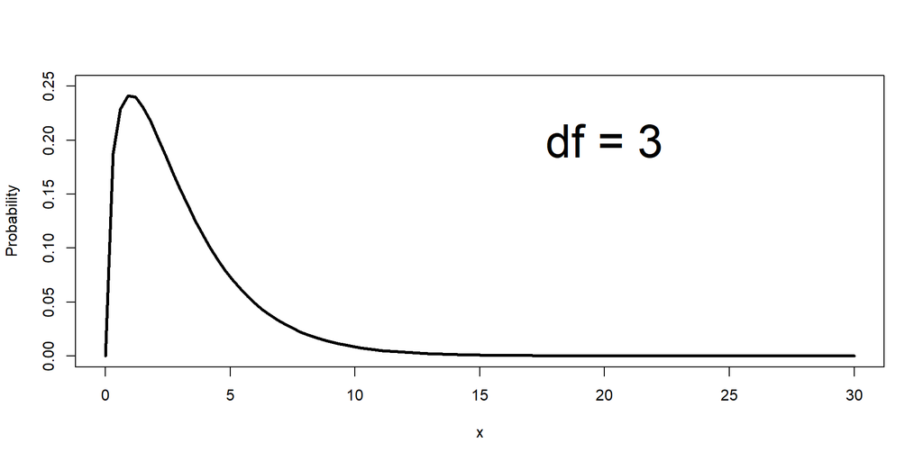

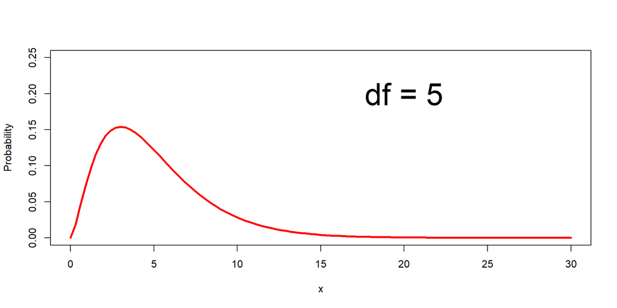

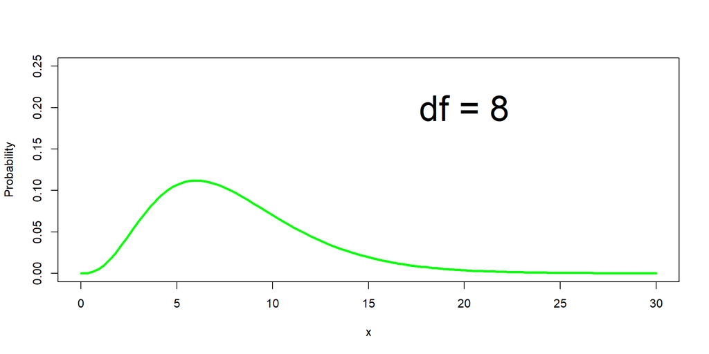

## Chi-squared Test

Let’s work with a concrete example:

$H_a$: Countries with lower levels of ethnic fractionalization (more linguistic/ethnic diversity) will be more likely to have a proportional representation system.

$H_0$: There’s no relationship between ethnic fractionalization and PR systems.

Here’s what our initial results look like:

| PR system? | High frac. | Low frac. |
| --- | --- | --- |
| No | 47 (60%) | 32 (44%) |
| Yes | 31 (40%) | 41 (56%) |

## A null hypothesis table

Our “null table” would be one that has same marginal (row/column) totals, but with no difference between high fractionalization and low fractionalization countries with respect to the DV.

| PR system? No | High frac. 47 (60%) | Low frac. 32 (44%) | Row Sums 79 |
| --- | --- | --- | --- |
| Yes | 31 (40%) | 41 (56%) | 72 |
| Total | 78 | 73 | 151 |

## Expected cell counts

We can calculate this for each cell with the formula:

$$\text{Row Total} \times \frac{\text{Column Total}}{\text{Total Number of observations}}$$

| PR system? No | High frac. | Low frac. | Row Sums 79 |
| --- | --- | --- | --- |
| Yes |  |  | 72 |
| Column Total | 78 | 73 | 151 |

## Expected cell counts

$$\text{Row Total} \times \frac{\text{Column Total}}{\text{Total Number of observations}}$$

| PR system? No | High frac. 79 x (78 / 151) = 40.81 | Low frac. 79 x (73/151) = 38.19 | Row Sums 79 |
| --- | --- | --- | --- |
| Yes | 72 x (78/151) = 37.19 | 72 x (73/151) = 34.81 | 72 |
| Column Total | 78 | 73 | 151 |

## Expected cell counts

Doing this for each cell would give us a table with equal proportions across each level of the IV.

| PR system? No | High frac. 40.81 (52%) | Low frac. 38.19 (52%) | Row Sums 79 |
| --- | --- | --- | --- |
| Yes | 37.19 (48%) | 34.81 (48%) | 72 |
| Column Total | 78 | 73 | 151 |

## Observed vs. Expected

Now, we need to calculate a test statistic that reflect how much the observed table differs from the table we expect under the null hypothesis.

We can get this by calculating the following for each cell and then summing up our result:

$$\frac{(\text{observed}-\text{expected})^2}{\text{expected}}$$

| PR system? No | High frac. (47 - 40.81)^2 / 40.81 = .94 | Low frac. (32 - 38.19)^2 / 38.19 = 1 | Row Sums 79 |
| --- | --- | --- | --- |
| Yes | (31 - 37.19)^2/37.19 = 1 | (41 - 34.81)^2/34.81 = 1.1 | 72 |
| Column Total | 78 | 73 | 151 |

$$\chi^2 = .94 + 1 + 1 + 1.1 \approx 4$$

## Degrees of Freedom

$$\chi^2 = .94 + 1 + 1 + 1.1 \approx 4$$

Finally, we need to know the degrees of freedom for our $\chi^2$ distribution. For this test, the degrees of freedom will equal:

$$\text{Degrees of freedom} = (\text{number of rows} - 1 ) \times (\text{number of columns} - 1)$$

We’ve got a two by two table, so that’s 1 x 1 = 1 degree of freedom.

## The P-value

With 1 degree of freedom, the probability of getting a $\chi^2$ statistic greater than or equal to 4 is about .046:

```r
pchisq(q=4, df=1, lower.tail=FALSE)
```

```
[1] 0.04550026
```

(as with Z-scores, this is based on our knowledge of the probability density function for this distribution:)

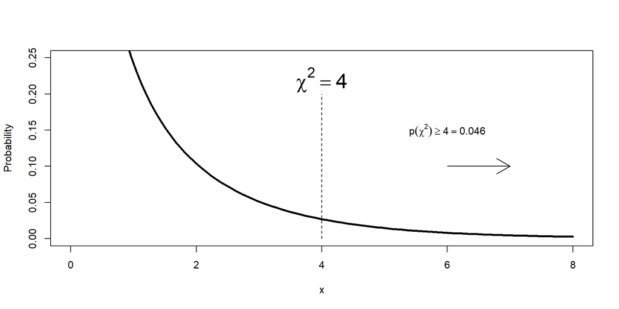

### Yates’ continuity correction

You’ll actually get a different result if you use R to calculate this:

```r
crosstabC(dv = pr.sys,
          iv = frac.eth2,
          chisq=TRUE,    # This will make the function include a Chisq statistic
          data =world)
```

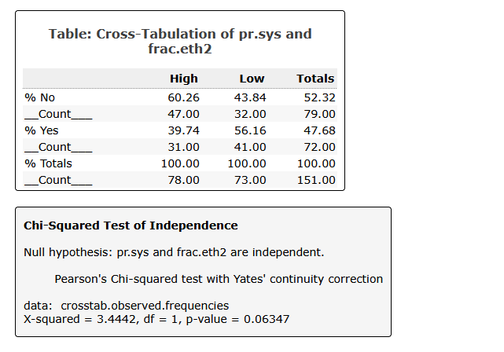

### Yates’ continuity correction

- This is because we’re using a continuous distribution, $\chi^2$ to approximate what’s actually a categorical outcome.
- For small samples it can cause us to estimate p-values that are too low. Yates’ correction subtracts a small amount from each cell count when calculating the $\text{observed} - \text{expected}$ values.

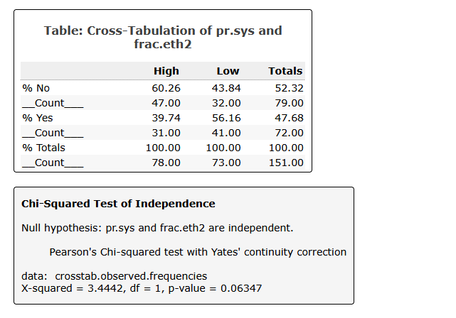

(This is not something that will come up on a homework, but don’t be thrown off if you see it)

## Chi-2 test Notes

- $\chi^2$ can work for testing a hypothesis about two categorical variables. (our examples here were all 2 x 2 tables, but it works just fine for 3 x 3 or more)
- It doesn’t tell you about the direction of the relationship, or really even the strength. It just tells you whether these variables are significantly related.
- For small samples $\chi^2$ sometimes estimates p-values that are too low. Most software (including R) will correct this automatically, but in practice Fisher’s Exact Test can be preferable for small samples.

# Hypothesis testing for continuous outcomes

## One or two samples?

- **One-sample significance tests:** is this mean different from some hypothetical value?
- **Two-sample significance tests:** are the means of these groups different from one another?

## One sample T-Test:

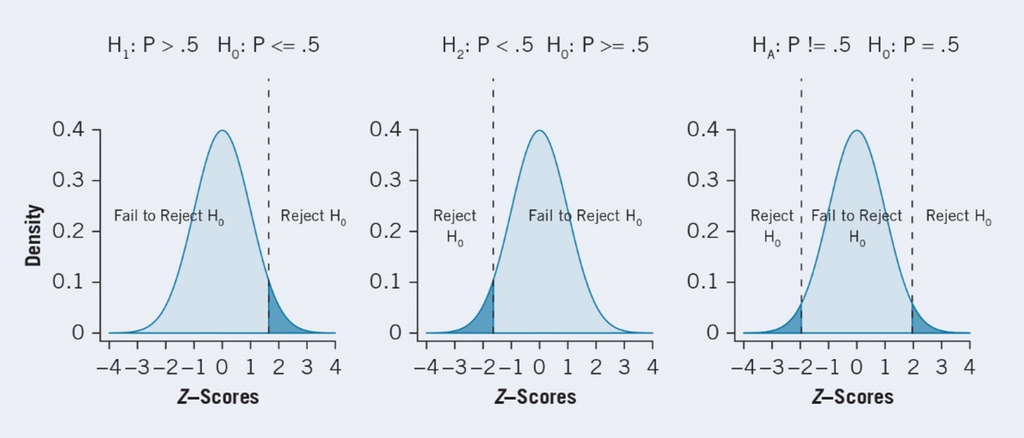

## One sample T-Test

I want to know if people are, on average, “warm” towards capitalists. I survey 100 people and get an average feeling thermometer score for “capitalists” was 54.3. Is it plausible that the actual population feeling thermometer score is actually 50 or below?

- $H_a$ The average FT for capitalists is greater than 50
- $H_0$ The average FT for capitalists is less than or equal to 50

My alpha here is .05, so I’ll reject the null if there’s a less than 5% chance of seeing a result this high if the null is true.

## One sample T-Test

Imagine the null is true, then the sampling distribution of sample means would be centered at 50 with a standard error equal to $\frac{\sigma}{\sqrt{n}}$

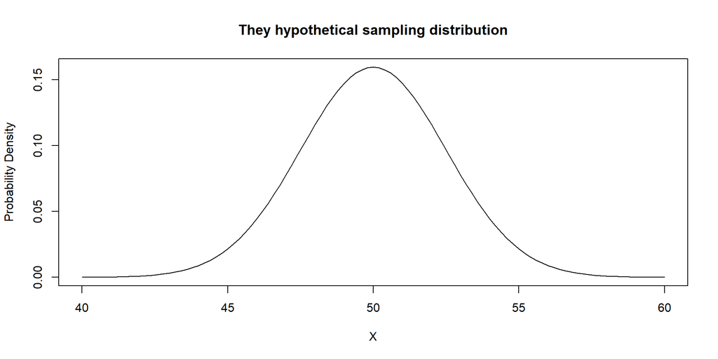

## One sample T-Test

Our **observed** value is 54.3. So, we’re basically asking: what is the probability of getting a result of 54.3 or greater if the population mean is 50?

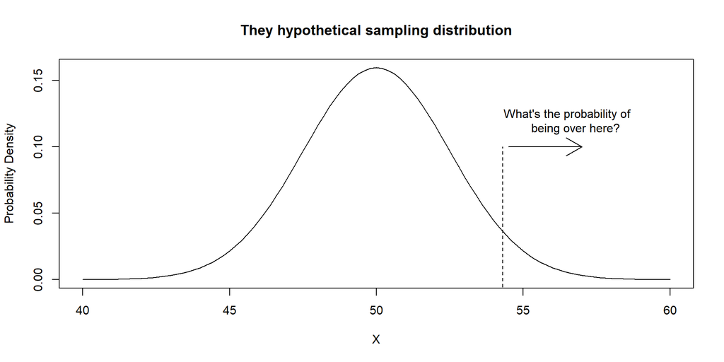

## One sample T-Test: P-value method

1. Calculate the difference between my observed value and the null value we’re assuming (50)
2. Calculate the standard error ($SE = \frac{s}{\sqrt{n}}$)
3. Calculate a T-statistic for this **difference** ($T = \frac{\text{difference}}{SE}$) and get the associated p.value

## One sample T-Test: P-value method

1. $54.3 - 50 = 4.3$ (that part’s easy)
2. $s = 25.2$; $n = 100$. So my standard error = $\frac{25.2}{\sqrt{100}} \approx 2.5$
3. $T = \frac{4.3}{2.5} \approx 1.7$, (with 99 degrees of freedom)

(Remember that, for large samples, T stats and Z stats will differ very little)

But I can calculate a P-value here if I’m feeling it:

```r
pt(1.7,
   df = 99,
   lower.tail=FALSE # we want to know the probability of getting a T > our observed T if the null is true
   )
```

```
[1] 0.04613535
```

## One sample T-Test: P-value method

Note that, if I flip my hypothesis I get a different answer:

$H_a:$ the population mean is less than 50

$H_0:$ the population mean greater than or equal to 50

```r
pt(1.7,
   df = 99,
   lower.tail=TRUE # this gives the probability of getting a T < our observed T if the null is true
   )
```

```
[1] 0.9538646
```

## One sample T-Test: P-value method

And a two-tailed test will double my p-value:

$H_a:$ the population mean is not 50

$H_0:$ the population is 50

```r
pt(1.7,
   df = 99,
   lower.tail=FALSE
   ) * 2 #we want to know the probability of getting a T score absolutely greater than what we observe
```

```
[1] 0.09227071
```

## One sample T-Test Confidence interval method

I could also test this hypothesis using a confidence interval. The two methods are based on the same assumptions, so they which you choose is mostly a matter of preference.

If the confidence range contains the null hypothesis value, then we fail to reject the null at that level.

A p-value of <.05 in a one-tailed test corresponds to a 90% confidence interval. The required T-score at 99 degrees of freedom is 1.67.

$$54.3 \pm 1.67 \times 2.5 = [50.13 , 58.5]$$

A p-value of <.05 in a two-tailed test corresponds to a 95% confidence interval. The required T-score at 99 degrees of freedom is 1.98.

$$54.3 \pm 1.98 \times 2.5 = [49.34 , 59.25]$$

## One sample tests for proportions

- The method here is roughly the same for proportions. The key difference is that we can use Z scores instead of the T-distribution because we don’t have to estimate the standard deviation.

## Two-Sample Test

In a two sample test, I want to know if estimates are different from one another.

In the (unweighted) NES data, respondents born before the collapse of the USSR have an average feeling thermometer rating towards socialists of 37.4. Those born after the collapse have an average rating of 46.8.

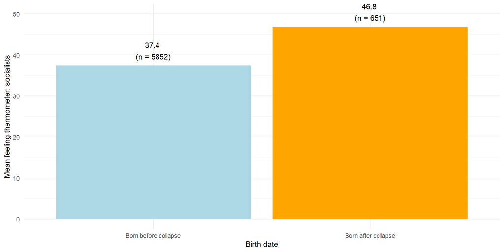

## Two-Sample Test

$H_a:$ those born after the end of the Cold War will have more positive feelings towards socialists compared to those born after

$H_0:$ those born after the end of the Cold War will have equal or more negative feelings compared to those born after.

(note that this is a one-tailed hypothesis)

So what’s the probability that people born after the Cold War ended would have a mean FT 9.4 points **higher** than those born after if the null hypothesis is true?

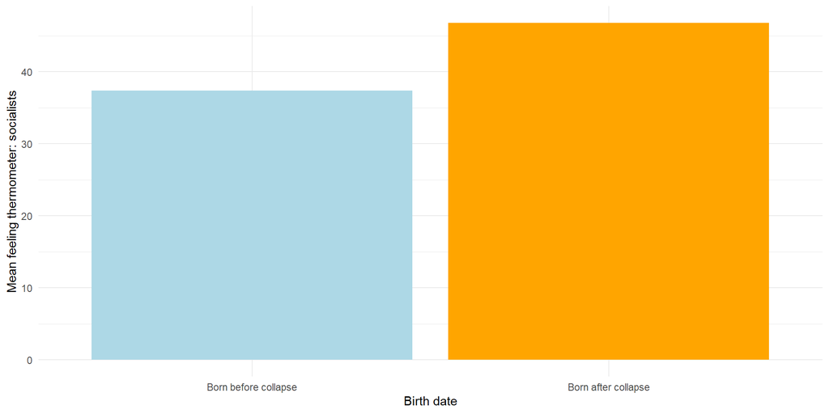

## Two-Sample Test

For a P-value:

1. Calculate the difference between the groups (46.8 - 37.4 = 9.4)
2. Calculate the standard error **of the difference**
3. Calculate a T-value from the difference divided by the standard error, and get an associated P-value

## Two-Sample Test

To get the standard error of the difference, we need to account for the fact that our estimates of both groups have some error associated with them. So we combine standard errors like this:

$$SE_{\text{diff}} = \sqrt{\frac{\sigma^2_{\text{group 1}}}{n_\text{group 1}} + \frac{\sigma^2_{\text{group 2}}}{n_\text{group 2}}}$$

## Two-Sample Test

$$\text{diff} = 46.8 - 37.4 = 9.4$$

$$T = \frac{9.4}{1.2} = 7.8$$

Degrees of freedom here is different depending on your assumptions about the samples, but a rule of thumb is to take N-1 for the smaller group. So $DF = 650$

## Two-Sample Test

So what’s the probability that people born after the Cold War ended would have a mean FT 9.4 points **higher** than those born after if the null hypothesis is true?

```r
pt(7.8, df=650, lower.tail = F)
```

```
[1] 1.236567e-14
```

Very small!

## Two-Sample Test

What about a two tailed test?

What’s the probability that people born after the Cold War ended would have a mean FT 9.4 points **higher or lower** than those born after if the null hypothesis is true?

```r
pt(7.8, df=650, lower.tail = F) * 2
```

```
[1] 2.473135e-14
```

Still significant

## Two-Sample Test: proportions

- As with the one sample case, the primary difference for testing a difference in proportions is that we can calculate $\sigma$ based on the proportion in our sample. So we can use Z instead of T.

# Review and Practice

- Consider this result from a recent YouGov survey on attitudes about the Middle Ages. N = 2,230
- Note that YouGov used an online opt-in panel here, so these results may not be representative, but we’ll ignore that

[figure not shown]

# How NOT to use p-values

## How to not use a p-value

Charles Cicchetti, writing in a deposition for the plaintiffs in a lawsuit claiming mass vote fraud swung the 2020 election, used a difference of means test to compare Biden’s 2020 results in Georgia to Clinton’s results in the same state. The goal was to “test the hypothesis that other things being equal they would have an equal number of votes”

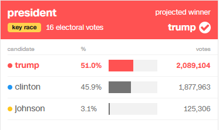

2016 outcome

[figure not shown]

2020 outcome

### How not to use a p-value

Clinton’s 2016 vote $= 45.9\%$ with $4,146,825$ total votes cast

Biden’s 2020 vote $= 49.5\%$ with $4,999,960$ total votes cast

$$\text{diff} = .495 - .459 = .036$$

$$\text{SE}_{\text{diff}} = \sqrt{\frac{.459 \times (1 - .459)}{4146825} + \frac{.495 \times (1-.495)}{4999960}} = 0.000331$$

$$Z = \frac{.036}{0.000331} = 108.7$$

$$P |Z| > z \approx 1 \text{ in } 1,000,000,000,000,000$$

### How not to use a p-value

> “In my opinion, the outcome of Biden winning is so statistically improbable, that it is not possible to dismiss fraud and biased changes in the ways ballots were processed, validated, and tabulated” - Charles Cicchetti

The math checks out! So what’s wrong with this claim?

What is the null hypothesis in this case? What can we conclude from rejecting it?

### How not to use a p-value

> if the objective is to assess whether Biden won legitimately, then it is beside the point whether Biden and Clinton enjoyed the same expected support. Support can differ across candidates for any number of reasons, and it is absurd to think that any such difference constitutes evidence of election fraud. -[Eggers, Garro, and Grimmer](https://www.pnas.org/doi/10.1073/pnas.2103619118)

(the authors go on to note that they can reject this null in every state in every presidential election since 1960)

This tells us that differences across elections aren’t random, but that’s probably not the most important question for researchers!

### What hypothesis testing does

In experimental research, “treatment” is randomly assigned, so once we’ve eliminated “random chance”, we can conclude the difference is due to the treatment.

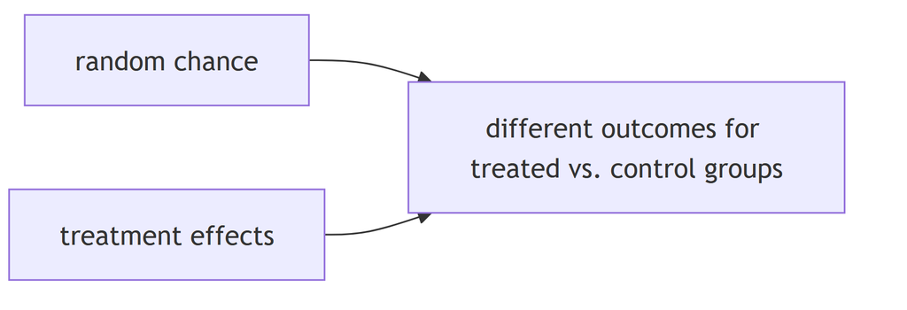

### What hypothesis testing does

In observational research, ruling out random chance is just the **first step** towards identifying a cause

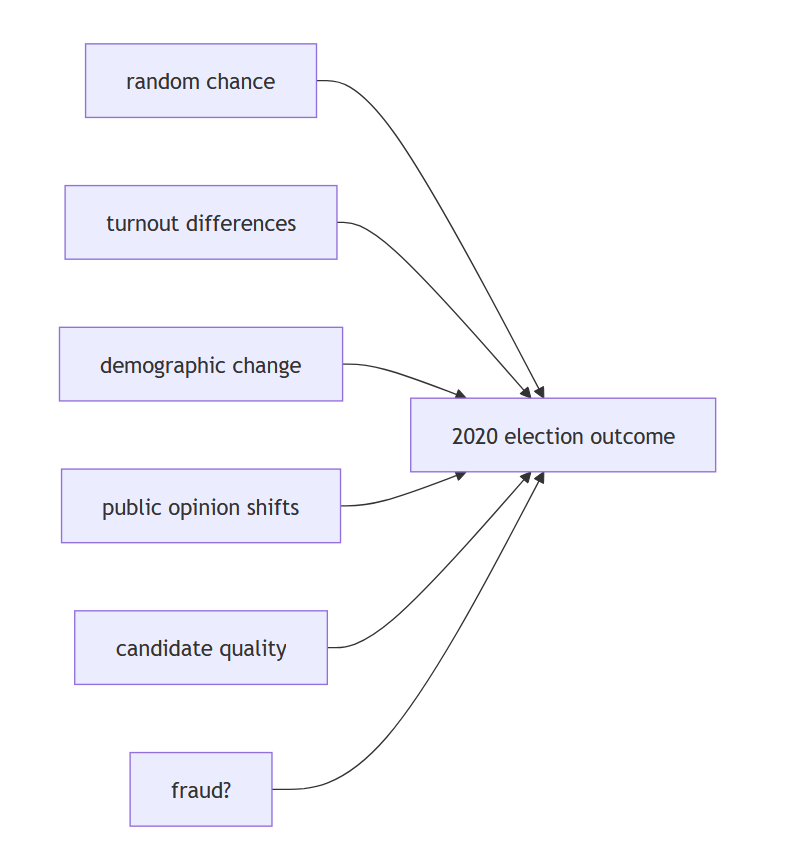

## Next week

Correlation and regression!